# Heatwave definition

M. Rolland

29/09/2020

# 1 Document Santé Publique France

*ÉVOLUTIONS DE L’EXPOSITION AUX CANICULES ET DE LA MORTALITÉ ASSOCIÉE EN FRANCE MÉTROPOLITAINE ENTRE 1970 ET 2013*

Forme de la relation:

> De nombreuses études épidémiologiques retrouvent ainsi une relation en J ou en U entre la température extérieure et la mortalité totale (ex (5-8)), soulignant une augmentation rapide de la mortalité vers les très fortes températures (Figure 1). Ces études, dont les résultats sont très cohérents à travers le monde, indiquent que la chaleur n’a pas besoin d’être extrême ni durable pour constituer un risque pour la santé. Toutefois, plus une chaleur sera inhabituelle, plus la part de la population qui éprouvera des difficultés à maintenir une thermorégulation efficace augmentera (1).

## 1.1 Calcul des seuils départementaux

> Les seuils ont donc été recalculés pour chaque département, en s’appuyant sur les travaux de confirmation des seuils du Sacs (18). Ils correspondent aux percentiles 99,5 calculés sur l’année entière, pour la période 1981-2010, et en incluant 2003.

## 1.2 Définition canicule analyse principale

> Une canicule est identifiée lorsque la température minimale moyennée sur trois jours, et la température maximale moyennée sur trois jours sont supérieures ou égales aux percentiles 99,5 de leur distribution respective (sur trois jours).

> $\frac{T_{min_i} + T_{min_{i-1}} + T_{min_{i-2}}}{3} \geq P_{99,5min}$ et $\frac{T_{max_i} + T_{max_{i-1}} + T_{max_{i-2}}}{3} \geq P_{99,5max}$

> Par définition, une canicule dure au moins trois jours, et démarre au jour i-2.

> Les canicules distantes de moins de trois jours sont reliées entre elles. Chaque jour de la canicule, une variable de sévérité est calculée comme la différence entre les températures moyennées sur trois jours et les percentiles 99,5 des températures moyennées sur trois jours.

> $severité_i = (\frac{T_{min_i} + T_{min_{i-1}} + T_{min_{i-2}}}{3} - P_{99,5min}) + (\frac{T_{max_i} + T_{max_{i-1}} + T_{max_{i-2}}}{3} - P_{99,5max})$

> La description des canicules s’appuie sur trois paramètres :
> - **La durée**, i.e. le nombre de jour entre le premier et le dernier jour de la vague de chaleur
> - **La sévérité cumulée**, qui correspond à la somme des sévérités journalières du premier au dernier jour de la canicule
> - **L’intensité**, qui représente la plus forte sévérité journalière observée pendant la canicule.

## 1.3 Définitions canicule alternartives: Annexe

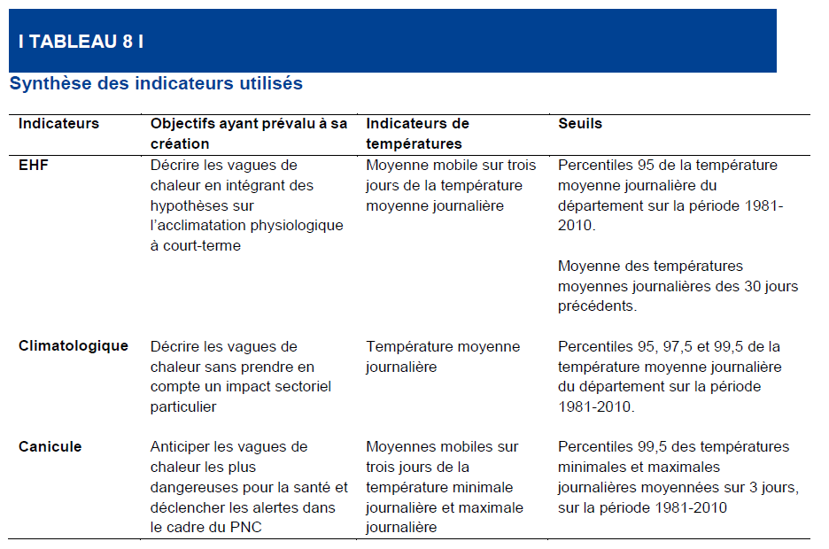

### 1.3.1 Excess heat factor

> L’Excess Heat Factor (EHF) prend en compte l’intensité par rapport à une référence historique, et par rapport aux jours précédents. Il est le seul indicateur affichant un objectif de normalisation de la description des vagues de chaleur pour des études sanitaires.

> L’EHF se décompose en un indicateur « historique » ($EHI_{sig}$) marquant un écart à un seuil historique, et un indicateur « d’acclimatation » ($EHI_{accl}$) marquant un écart à la température des 30 jours précédents.

> $EHI_{sig}$ se calcule à partir de la moyenne mobile sur trois jours des températures moyennes journalières :

$$EHI_{sig} = \frac{\sum^{3}_{j=1}T_{moy_{i-j}}}{3} - P_{95}$$

> P95 est le percentile 95 de la distribution des températures moyennes journalières, année entière, sur la période 1981-2010. La vague de chaleur démarre au jour i-2. Les valeurs départementales de P95 sont en Annexe 1.

> $EHI_{accl}$ compare la moyenne sur trois jours des températures moyennes journalières à la moyenne sur trente jours des températures moyennes journalières :

$$EHI_{accl} = \frac{\sum^{3}_{j=1}T_{moy_{i-j}}}{3} - \frac{\sum^{30}_{j=1}T_{moy_{i-j}}}{30}$$

> L’indicateur global est calculé comme le produit de ces deux indicateurs, en considérant :
> - qu’il n’y a vague de chaleur que si les températures sont plus élevées que les normales historiques, i.e. $EHI_{sig}$>0
> - que cette vague de chaleur n’est aggravée par un risque de mauvaise acclimatation que si la température est au moins 1°C supérieure à celles des trente jours précédents :

$$EHF = max(0, EHI_{sig})*max(1, EHI_{accl})$$

> Les vagues de chaleur distantes de moins de trois jours sont reliés entre elles.

Définition du P95:

Cf (@ Nairn and Fawcett 2014)

### 1.3.2 Indicateur météo-france (“climatologique”)

> Cet indicateur a été développé par Météo-France afin de caractériser les vagues de chaleur notamment en terme de durée, d’intensité maximale et d’intensité cumulée (sévérité), sans notion d’impact dans un secteur particulier. Il définit une canicule à partir de trois seuils :
> - **Spic** : seuil de pic de chaleur, correspondant au percentile 99,5 de la température moyenne journalière du département sur la période 1981-2010.
> - **Sdeb** : seuil indiquant les dates de début et de fin de l’épisode, correspondant au percentile 97,5 de la température moyenne journalière du département sur la période 1981-2010.
> - **Sint** : seuil d’interruption : correspondant au percentile 95 de la température moyenne journalière du département sur la période 1981-2010.

> Une vague de chaleur est identifiée dès lors que la température moyenne dépasse le percentile 99,5 (Spic). Les jours entourant ce pic sont inclus dans la période de vague de chaleur lorsque leur température moyenne est supérieure au percentile 97,5 (Sdeb). La vague de chaleur est interrompue si la température descend pendant au moins trois jours successifs en dessous de percentile 97,5 (Sdeb) ou si elle passe même pour une seule journée en deça du percentile 95 (Sint).

> Seules les vagues de chaleur durant au moins trois jours sont conservées dans l’analyse. Les vagues de chaleur distantes de moins de trois jours sont reliés entre elles, sauf si la température est inférieure à Sint pendant ces jours.

## 1.4 Autres notes

Température apparente/ressentie = indice combinant température sèche, humidité et vent.

# 2 Autre sources

## 2.1 (Nairn and Fawcett 2014): Excess Heat Factor (EHF)

Indicator developped in the context of heat related mortality.

Justification 3 day period:

> The choice of a three-day period (TDP) over which to calculate heatwave indices is motivated by studies of human responses to the onset of extremely hot weather.

> In that event, it takes three days of very hot weather for the mortality rate to rise significantly above its antecedent rate.

Refs détaillées ds le papier.

Regarding humidity:

> Relative humidity can be an important consideration in assessing the human health effects of heatwaves. It is not observed and forecast as well as air temperature, however. On this basis we have chosen not to include it explicitly in our new heatwave metric. It does, however, have an implicit presence through our inclusion of daily minimum temperature. High humidity tends to result in high minimum temperature, and low humidity in low minima, and this will be reflected in our DMT calculation.

Extension of the formula to coldwaves:

> We note that the methodology described here is readily adapted to provide an analogous formulation for coldwave monitoring and prediction

P95:

> annual temperature threshold at each particular location

Length of heatwave:

> On average, around 18 days per year will have a DMT exceeding T95, but it is necessary to have three high DMTs in succession in order to form a heatwave according to this characterisation

## 2.2 (McMichael et al., n.d.)

Acclimatation et forme de la relation dose-reponse (en U)

# 3 Definition of P95

## 3.1 (Chen et al. 2015)

Study period whole year

## 3.2 (Wang et al. 2013)

Study period whole year

## 3.3 (Wang et al. 2020)

Study period whole year

## 3.4 (Tobias et al. 2012)

Hot months (June - September) of study period

## 3.5 (Cox et al. 2016)

Study period whole year

# References

Chen, Kai, Jun Bi, Jin Chen, Xiaodong Chen, Lei Huang, and Lian Zhou. 2015. “Influence of Heat Wave Definitions to the Added Effect of Heat Waves on Daily Mortality in Nanjing, China.” *Science of the Total Environment* 506-507 (February): 18–25. https://doi.org/10.1016/j.scitotenv.2014.10.092.

Cox, Bianca, Ana M Vicedo-Cabrera, Antonio Gasparrini, Harry A Roels, Evelyne Martens, Jaco Vangronsveld, Bertil Forsberg, and Tim S Nawrot. 2016. “Ambient Temperature as a Trigger of Preterm Delivery in a Temperate Climate.” *Journal of Epidemiology and Community Health* 70 (12): 1191–9. https://doi.org/10.1136/jech-2015-206384.

McMichael, Anthony J, Paul Wilkinson, R Sari Kovats, Sam Pattenden, Shakoor Hajat, Ben Armstrong, Nitaya Vajanapoom, et al. n.d. “International Study of Temperature, Heat and Urban Mortality: The ‘ISOTHURM’ Project,” 11.

Nairn, John, and Robert Fawcett. 2014. “The Excess Heat Factor: A Metric for Heatwave Intensity and Its Use in Classifying Heatwave Severity.” *International Journal of Environmental Research and Public Health* 12 (1): 227–53. https://doi.org/10.3390/ijerph120100227.

Tobias, Aurelio, Ben Armstrong, Ines Zuza, Antonio Gasparrini, Cristina Linares, and Julio Diaz. 2012. “Mortality on Extreme Heat Days Using Official Thresholds in Spain: A Multi-City Time Series Analysis.” *BMC Public Health* 12 (1): 133. https://doi.org/10.1186/1471-2458-12-133.

Wang, J, G Williams, Y Guo, X Pan, and S Tong. 2013. “Maternal Exposure to Heatwave and Preterm Birth in Brisbane, Australia.” *BJOG: An International Journal of Obstetrics & Gynaecology* 120 (13): 1631–41. https://doi.org/10.1111/1471-0528.12397.

Wang, Qiong, Bing Li, Tarik Benmarhnia, Shakoor Hajat, Meng Ren, Tao Liu, Luke D. Knibbs, et al. 2020. “Independent and Combined Effects of Heatwaves and PM2.5 on Preterm Birth in Guangzhou, China: A Survival Analysis.” *Environmental Health Perspectives* 128 (1): 017006. https://doi.org/10.1289/EHP5117.